# NOAA Events analysis

## Introduction

In this document we will explore the NOAA Storm database and try to create insights that can help prevent and reduce the impact of this kind of events. We will be using the [NOAA database] (https://d396qusza40orc.cloudfront.net/repdata%2Fdata%2FStormData.csv.bz2) obtained on Mon Jul 27 01:26:32 2015

## Data processing

Let’s load and prepare data:

```r
#### load data
# variable initialisation
zipfile = "./repdata-data-StormData.csv.bz2"

# set working directory
setwd("/Users/inesv/Coursera/5-Replicable/w3")

# load data, if not done yet
if(!(exists("NOAA"))){
    NOAA <- read.csv(zipfile)
    }
```

We create a new dataframe ‘damages’ containing only the data referred to personal and material damage and event type.

```r
#### Prepare data
# Goal understand: which events have highest consequences for humans and for the economy.
# interesting fields are FATALITIES, INJURIES, PROPDMG, CROPDMG, PROPDMGEXP, CROPDMGEXP
# PROPDMGEXP, CROPDMGEXP need to be interpreted
# From the manual: Estimates should be rounded to three significant digits,
# followed by an alphabetical character signifying the magnitude of the
# number, i.e., 1.55B for $1,550,000,000. Alphabetical characters used to signify magnitude
# include ???K??? for thousands, ???M??? for millions, and ???B??? for billions.

## Create two new variables to indicate damage in dollars.
# Organise data
damages <- NOAA %>%
    select(EVTYPE, PROPDMG, CROPDMG, PROPDMGEXP, CROPDMGEXP, FATALITIES, INJURIES)

# Keep only events with economic or personal damage
#damages <- filter(events, !(events$PROPDMG == 0 & events$CROPDMG == 0) |
#  !(events$FATALITIES == 0 & events$INJURIES))

# Set to uppercase
damages$PROPDMGEXP <- toupper(damages$PROPDMGEXP)
damages$CROPDMGEXP <- toupper(damages$CROPDMGEXP)
damages$EVTYPE <- toupper(damages$EVTYPE)
# remove double spaces + spaces at the beginning or at the end
damages$EVTYPE <- gsub("^ +| +$|( ) +", "\\1", damages$EVTYPE, perl=TRUE)
```

We create a dictionary to associate the different event types to the conventions described in the [NOAA manual] (https://d396qusza40orc.cloudfront.net/repdata%2Fpeer2_doc%2Fpd01016005curr.pdf)

```r
names <- c("key", "terms")
dic <- vector("character", length(names))
names(dic) <- names

dic$terms <- c(
    #Winter Storm Z
    "WIND(.+)SNOW|SNOW(.+)WIND|SNOW(.*)SLEET|FREEZ(.+)RAIN(.+)SNOW|SLEET(.+)ICE|FREEZ|RAIN(.+)SLEET(.+)SNOW|ICE(.+)SNOW|BLOW(.+)SNOW|SNOW(.+)BLOW|BLIZZ(.+)SNOW|ICE(.+)WIND|SNOW(.+)BLIZ|SNOW(.+)SQUALLS|HEAVY SNOW(.+)HIGH WINDS, SNOW/RAIN/SLEET",
    #Thunderstorm Wind C
    "^THUNDERSTORM WIND|^TSTM WIND",
    #High Wind Z
    "^HIGH(.+)WIND",
    #Astronomical Low Tide Z
    "BLOW-OUT|ASTRONOMICAL LOW TIDE",
    #Avalanche Z
    "AVALANC|DRIFTING SNOW",
    #Blizzard Z
    "BLIZZARD",
    #Coastal Flood Z
    "BEACH|COASTAL FLOOD|HIGH TIDE",
    #Cold/Wind Chill Z
    "COLD WIND CHILL",
    #Debris Flow C
    "DEBRIS",
    #Dense Fog Z
    "^FOG|DENSE FOG|ICE FOG",
    #Dense Smoke Z
    "SMOKE",
    #Drought Z
    "DRY|DROUGHT",
    #Dust Devil C
    "DEVIL",
    #Dust Storm Z
    "DUST",
    #Excessive Heat Z
    "HEAT",
    #Extreme Cold/Wind Chill Z
    "EXTREME(.+)COLD|WIND(.+)CHILL",
    #Flash Flood C
    "FLASH | FLOOD",
    #Flood C
    "FLOOD",
    #Frost/Freeze Z
    "FROST|FREEZE",
    #Funnel Cloud C
    "FUNNEL",
    #Freezing Fog Z
    "FREEZING FOG",
    #Hail C
    "HAIL",
    #Heat Z
    "HEAT",
    #Heavy Rain C
    "HEAVY(.+)RAIN",
    #Heavy Snow Z
    "HEAVY(.+)SNOW",
    #High Surf Z
    "HIGH SURF",
    #Hurricane (Typhoon) Z
    "HURRICANE|TYPHOON",
    #Ice Storm Z
    "ICESTORM",
    #Lake-Effect Snow Z
    "LAKE SNOW|EFFECT SNOW",
    #Lakeshore Flood Z
    "LAKE FLOOD|LAKESHORE FLOOD",
    #Lightning C
    "LIGHTNING",
    #Marine Hail M
    "MARINE HAIL",
    #Marine High Wind M: we include here 2 "MARINE MISHAP" reported with 40mph+ winds, and one "MARINE ACCIDENT" (Fatalities resulting from drowning due to an overturned, damaged, or destroyed marine vessel)
    "MARINE HIGH WIND|MARINE MISHAP|MARINE ACCIDENT",
    #Marine Strong Wind M
    "MARINE STRONG WIND",
    #Marine Thunderstorm Wind M
    "MARINE TSTM WIND|MARINE THUNDERSTORM WIND",
    #Rip Current Z
    "RIP CURRENT",
    #Seiche Z
    "SEICHE",
    #Sleet Z
    "SLEET",
    #Storm Surge/Tide Z
    "SURGE",
    #Strong Wind Z
    "^STRONG WIND",
    #Tornado C
    "TORNADO",
    #Tropical Depression Z
    "TROPICAL DEPRESSION",
    #Tropical Storm Z
    "TROPICAL STORM",
    #Tsunami Z
    "TSUNAMI",
    #Volcanic Ash Z
    "VOLCAN",
    #Waterspout M
    "WATERSPROUT",
    #Wildfire Z
    "WILDFIRE",
    #Winter Weather Z
    "SNOW(.+)COLD")
dic$key <- c(
    #Winter Storm Z
    "WINTER STORM",
    #Thunderstorm Wind C
    "THUNDERSTORM WIND",
    #High Wind Z
    "HIGH WIND",
    #Astronomical Low Tide Z
    "ASTRONOMICAL LOW TIDE",
    #Avalanche Z
    "AVALANCHE",
    #Blizzard Z
    "BLIZZARD",
    #Coastal Flood Z
    "COASTAL FLOOD",
    #Cold/Wind Chill Z
    "COLD/WIND CHILL",
    #Debris Flow C
    "DEBRIS FLOW",
    #Dense Fog Z
    "DENSE FOG",
    #Dense Smoke Z
    "DENSE SMOKE",
    #Drought Z
    "DROUGHT",
    #Dust Devil C
    "DUST DEVIL",
    #Dust Storm Z
    "DUST STORM",
    #Excessive Heat Z
    "EXCESSIVE HEAT",
    #Extreme Cold/Wind Chill Z
    "EXTREME COLD/WIND CHILL",
    #Flash Flood C
    "FLASH FLOOD",
    #Flood C
    "FLOOD",
    #Frost/Freeze Z
    "FROST/FREEZE",
    #Funnel Cloud C
    "FUNNEL CLOUD",
    #Freezing Fog Z
    "FREEZING FOG",
    #Hail C
    "HAIL",
    #Heat Z
    "HEAT",
    #Heavy Rain C
    "HEAVY RAIN",
    #Heavy Snow Z
    "HEAVY SNOW",
    #High Surf Z
    "HIGH SURF",
    #Hurricane (Typhoon) Z
    "HURRICANE/TYPHOON",
    #Ice Storm Z
    "ICE STORM",
    #Lake-Effect Snow Z
    "LAKE-EFFECT SNOW",
    #Lakeshore Flood Z
    "LAKESHORE FLOOD",
    #Lightning C
    "LIGHTNING",
    #Marine Hail M
    "MARINE HAIL",
    #Marine High Wind M
    "MARINE HIGH WIND",
    #Marine Strong Wind M
    "MARINE STRONG WIND",
    #Marine Thunderstorm Wind M
    "MARINE THUNDERSTORM WIND",
    #Rip Current Z
    "RIP CURRENT",
    #Seiche Z
    "SEICHE",
    #Sleet Z
    "SLEET",
    #Storm Surge/Tide Z
    "STORM SURGE/TIDE",
    #Strong Wind Z
    "STRONG WIND",
    #Tornado C
    "TORNADO",
    #Tropical Depression Z
    "TROPICAL DEPRESSION",
    #Tropical Storm Z
    "TROPICAL STORM",
    #Tsunami Z
    "TSUNAMI",
    #Volcanic Ash Z
    "VOLCANIC ASH",
    #Waterspout M
    "WATERSPROUT",
    #Wildfire Z
    "WILDFIRE",
    #Winter Weather Z
    "WINTER WEATHER")
```

We unify the different denominations to event types ‘EVTYPE’ into the new column ‘type’ using the dictionary above:

```r
# initialise column to flag events already unified
damages$fixed <- FALSE

for (i in 1:length(dic$key)) {
    # find current EVTYPES in dictionary and find corresponding 'key'
    fit_dictionary <- grepl(dic$terms[i], damages$EVTYPE)
    #make sure we don't correct events already fixed
    to_replace <- fit_dictionary & !damages$fixed

    damages$type[to_replace] <- toString(dic$key[i])

    # update fixed index
    damages$fixed[to_replace] <- TRUE
    }
```

```r
# apply multipliers to convert to millions of dollars
multipliers <- data.frame(letter = c("B", "M", "K"), number = c(1e3, 1, 1e-3)) # faltan el H y los n??meros
# initialise value for damages to property and crops in $
damages$property <- 0
damages$crop <- 0
for ( i in 1:length(multipliers$letter)) {
    prop_units_to_convert <- damages$PROPDMGEXP == multipliers$letter[i]
    damages$property[prop_units_to_convert] <-
        damages$PROPDMG[prop_units_to_convert] * multipliers$number[i]
    crop_units_to_convert <- damages$CROPDMGEXP == multipliers$letter[i]
    damages$crop[crop_units_to_convert] <-
        damages$CROPDMG[crop_units_to_convert] * multipliers$number[i]
    }
```

We aggregate damages to property, crops and humans to be able to compare the different event types.

```r
class(damages$type)
```

```
## [1] "character"
```

```r
class(dic$key[1])
```

```
## [1] "character"
```

```r
conclusions <- damages %>%
    group_by(type) %>%
    summarise(sum_property = sum(property),
              sum_crop = sum(crop),
              total_impact = sum(property, crop),
              sum_deaths = sum(FATALITIES),
              sum_blessed = sum(INJURIES)) %>%
    arrange(sum_deaths)
```

```r
table <- xtable(conclusions)
print(table, type= "html")
```

|  | type | sum_property | sum_crop | total_impact | sum_deaths | sum_blessed |
| --- | --- | --- | --- | --- | --- | --- |
| 1 | ASTRONOMICAL LOW TIDE | 0.32 | 0.00 | 0.32 | 0.00 | 0.00 |
| 2 | COLD/WIND CHILL | 0.00 | 0.00 | 0.00 | 0.00 | 0.00 |
| 3 | DEBRIS FLOW | 0.00 | 0.00 | 0.00 | 0.00 | 0.00 |
| 4 | DENSE SMOKE | 0.10 | 0.00 | 0.10 | 0.00 | 0.00 |
| 5 | FUNNEL CLOUD | 0.19 | 0.00 | 0.19 | 0.00 | 3.00 |
| 6 | LAKE-EFFECT SNOW | 40.18 | 0.00 | 40.18 | 0.00 | 0.00 |
| 7 | SEICHE | 0.98 | 0.00 | 0.98 | 0.00 | 0.00 |
| 8 | TROPICAL DEPRESSION | 1.74 | 0.00 | 1.74 | 0.00 | 0.00 |
| 9 | VOLCANIC ASH | 0.50 | 0.00 | 0.50 | 0.00 | 0.00 |
| 10 | FROST/FREEZE | 0.01 | 108.00 | 108.02 | 1.00 | 3.00 |
| 11 | WINTER WEATHER | 1.05 | 0.00 | 1.05 | 1.00 | 0.00 |
| 12 | DUST DEVIL | 0.72 | 0.00 | 0.72 | 2.00 | 43.00 |
| 13 | SLEET | 0.00 | 0.00 | 0.00 | 2.00 | 0.00 |
| 14 | COASTAL FLOOD | 437.14 | 0.06 | 437.20 | 6.00 | 7.00 |
| 15 | MARINE HIGH WIND | 1.35 | 0.00 | 1.35 | 9.00 | 8.00 |
| 16 | MARINE STRONG WIND | 0.42 | 0.00 | 0.42 | 14.00 | 22.00 |
| 17 | MARINE THUNDERSTORM WIND | 5.86 | 0.05 | 5.91 | 19.00 | 34.00 |
| 18 | WINTER STORM | 58.46 | 1889.08 | 1947.54 | 20.00 | 96.00 |
| 19 | DUST STORM | 5.62 | 3.60 | 9.22 | 22.00 | 440.00 |
| 20 | STORM SURGE/TIDE | 47965.22 | 0.85 | 47966.08 | 24.00 | 43.00 |
| 21 | TSUNAMI | 144.06 | 0.02 | 144.08 | 33.00 | 129.00 |
| 22 | DROUGHT | 1053.04 | 13972.64 | 15025.68 | 38.00 | 48.00 |
| 23 | HAIL | 17574.57 | 3049.44 | 20624.01 | 40.00 | 1371.00 |
| 24 | TROPICAL STORM | 7714.39 | 694.90 | 8409.29 | 66.00 | 383.00 |
| 25 | WILDFIRE | 4865.61 | 295.97 | 5161.59 | 75.00 | 911.00 |
| 26 | DENSE FOG | 22.83 | 0.00 | 22.83 | 81.00 | 1077.00 |
| 27 | HEAVY RAIN | 3225.57 | 795.40 | 4020.97 | 98.00 | 255.00 |
| 28 | BLIZZARD | 659.81 | 112.06 | 771.87 | 101.00 | 805.00 |
| 29 | STRONG WIND | 177.67 | 69.95 | 247.63 | 111.00 | 301.00 |
| 30 | HEAVY SNOW | 939.85 | 134.65 | 1074.51 | 127.00 | 1033.00 |
| 31 | HURRICANE/TYPHOON | 85356.41 | 5516.12 | 90872.53 | 135.00 | 1333.00 |
| 32 | HIGH SURF | 100.03 | 0.00 | 100.03 | 146.00 | 204.00 |
| 33 | AVALANCHE | 3.72 | 0.00 | 3.72 | 225.00 | 170.00 |
| 34 | HIGH WIND | 6003.16 | 686.30 | 6689.46 | 290.00 | 1464.00 |
| 35 | EXTREME COLD/WIND CHILL | 78.43 | 1313.62 | 1392.05 | 382.00 | 267.00 |
| 36 | FLOOD | 144787.84 | 5784.03 | 150571.87 | 477.00 | 6791.00 |
| 37 | RIP CURRENT | 0.16 | 0.00 | 0.16 | 577.00 | 529.00 |
| 38 |  | 16076.40 | 5525.61 | 21602.01 | 687.00 | 5636.00 |
| 39 | THUNDERSTORM WIND | 9760.53 | 1224.40 | 10984.93 | 709.00 | 9468.00 |
| 40 | LIGHTNING | 933.70 | 12.09 | 945.79 | 817.00 | 5232.00 |
| 41 | FLASH FLOOD | 22307.75 | 6595.98 | 28903.73 | 1042.00 | 1806.00 |
| 42 | EXCESSIVE HEAT | 20.13 | 904.41 | 924.54 | 3132.00 | 9209.00 |
| 43 | TORNADO | 56993.10 | 414.96 | 57408.06 | 5636.00 | 91407.00 |

## Results

### Harmfulness

```r
# Across the United States, which types of events (as indicated in the EVTYPE variable) are most harmful with respect to population health?
arrange(conclusions, desc(sum_deaths))
```

```
## Source: local data frame [43 x 6]
##
##                       type sum_property   sum_crop total_impact sum_deaths
## 1                  TORNADO  56993.09773  414.96136   57408.0591       5636
## 2           EXCESSIVE HEAT     20.12575  904.41350     924.5393       3132
## 3              FLASH FLOOD  22307.75446 6595.97615   28903.7306       1042
## 4                LIGHTNING    933.69928   12.09209     945.7914        817
## 5        THUNDERSTORM WIND   9760.53403 1224.39790   10984.9319        709
## 6                       NA  16076.40106 5525.60968   21602.0107        687
## 7              RIP CURRENT      0.16300    0.00000       0.1630        577
## 8                    FLOOD 144787.84480 5784.02695  150571.8717        477
## 9  EXTREME COLD/WIND CHILL     78.42540 1313.62300    1392.0484        382
## 10               HIGH WIND   6003.15591  686.30190    6689.4578        290
## ..                     ...          ...        ...          ...        ...
## Variables not shown: sum_blessed (dbl)
```

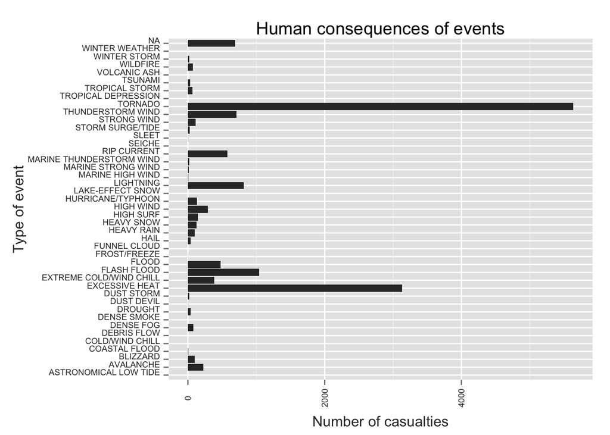

```r
c <- ggplot(data = conclusions, aes(y = sum_deaths, x = type)) +
    geom_bar(position="dodge",stat="identity") +
    coord_flip() +
    xlab("Type of event") + ylab("Number of casualties") + ggtitle("Human consequences of events") +
    theme(axis.text.x = element_text(colour="grey20",size=7,angle=90,hjust=.5,vjust=.5,face="plain"),
          axis.text.y = element_text(colour="grey20",size=7,angle=0,hjust=1,vjust=0,face="plain"),
          axis.title.x = element_text(colour="grey20",size=12,angle=0,hjust=.5,vjust=0,face="plain"),
          axis.title.y = element_text(colour="grey20",size=12,angle=90,hjust=.5,vjust=.5,face="plain"))
print(c)
```

### Economic consequences

```r
## Across the United States, which types of events have the greatest economic consequences?
arrange(conclusions, desc(total_impact))
```

```
## Source: local data frame [43 x 6]
##
##                 type sum_property   sum_crop total_impact sum_deaths
## 1              FLOOD   144787.845  5784.0270   150571.872        477
## 2  HURRICANE/TYPHOON    85356.410  5516.1178    90872.528        135
## 3            TORNADO    56993.098   414.9614    57408.059       5636
## 4   STORM SURGE/TIDE    47965.224     0.8550    47966.079         24
## 5        FLASH FLOOD    22307.754  6595.9761    28903.731       1042
## 6                 NA    16076.401  5525.6097    21602.011        687
## 7               HAIL    17574.569  3049.4376    20624.006         40
## 8            DROUGHT     1053.039 13972.6368    15025.675         38
## 9  THUNDERSTORM WIND     9760.534  1224.3979    10984.932        709
## 10    TROPICAL STORM     7714.391   694.8960     8409.287         66
## ..               ...          ...        ...          ...        ...
## Variables not shown: sum_blessed (dbl)
```

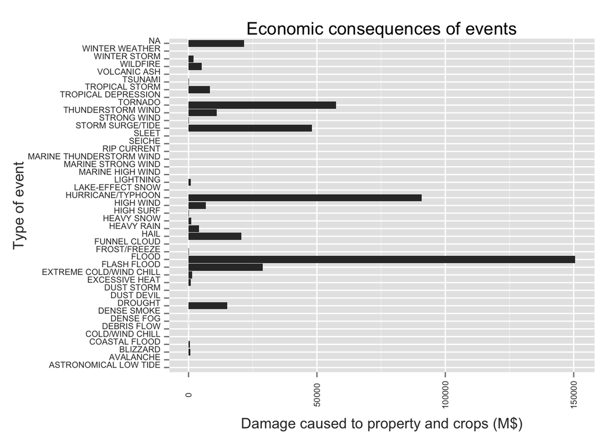

```r
a <- ggplot(data = conclusions, aes(y = total_impact, x = type)) +
    geom_bar(position="dodge",stat="identity") +
    coord_flip() +
    xlab("Type of event") + ylab("Damage caused to property and crops (M$)") +
    ggtitle("Economic consequences of events") +
    theme(axis.text.x = element_text(colour="grey20",size=7,angle=90,hjust=.5,vjust=.5,face="plain"),
          axis.text.y = element_text(colour="grey20",size=7,angle=0,hjust=1,vjust=0,face="plain"),
          axis.title.x = element_text(colour="grey20",size=12,angle=0,hjust=.5,vjust=0,face="plain"),
          axis.title.y = element_text(colour="grey20",size=12,angle=90,hjust=.5,vjust=.5,face="plain"))
print(a)
```

Based on the analytics above ‘Flood’, ‘Hurricane/Typhoon’ and ‘Tornado’ are the most harmfull to economy, in terms of property and crop damage. Further study on affected areas and size of the damage could help applying the appropriate mitigation plans, such as insurance or diversification.